# Python Programming for Petroleum Engineers

## HW1 (Pyhton Hands-on)

### Novin Nekuee

#### Student_id: 403134029

Welcome to this comprehensive set of Python exercises tailored specifically for petroleum engineering students! These exercises are designed to challenge your understanding of Python programming concepts and their applications in the oil and gas industry.

Throughout this notebook, you will encounter a wide range of exercises that cover various Python topics, including data structures, control flow statements, functions, modules, NumPy arrays, Pandas dataframes, and data visualization with Matplotlib. Each exercise is carefully crafted to incorporate real-world petroleum engineering scenarios, ensuring that you gain practical experience in applying Python to solve problems relevant to your field.

Whether you're a beginner or an experienced programmer, these exercises will help you strengthen your Python skills and develop a deeper understanding of how programming can be leveraged to tackle complex problems in the petroleum industry.

In addition to coding exercises, you will also encounter debugging challenges and error handling scenarios, which will help you develop the critical thinking skills necessary for effective troubleshooting and problem-solving.

Remember, programming is a continuous learning process, and these exercises are meant to be challenging. Don't hesitate to seek help from your instructors, classmates, or online resources when needed. Collaboration and knowledge sharing are key elements of successful programming. But first try to challenge your brain improve your skills.

So, let's embark on this exciting journey and dive into the world of Python programming for petroleum engineers!

### Task 1: Well Distances Calculation

In this task, you will work with well coordinates and calculate the distances between pairs of wells.

Part 1: Generate Well Coordinates

1. Use the provided function `generate_well_coordinates(student_id)` with your student ID as input to generate 10 random (x, y) tuples representing well coordinates.
2. Print the list of well coordinates to ensure you have the correct data.

Part 2: Calculate Well Distances

1. Create a nested list (10 x 10) to store the distances between each pair of wells.
2. Use the Pythagorean theorem to calculate the distance between each pair of wells, and store the distances in the nested list.
3. Print the nested list of well distances.

Part 3: Find Minimum and Maximum Distances

1. Write a function to take well coordinates list as input then find and returns the two wells with the minimum distance between them, and print their indices and corresponding distance.
2. Write a function to take well coordinates list as input then find and returns the maximum distance between them, and print their indices and corresponding distance.

Extra Points: Well Coordinates Plot Plot the well coordinates and draw the two wells with least distance with different colors on it.

```python
import random

def generate_well_coordinates(student_id):
    """
    Generates 10 random (x, y) tuples representing well coordinates.

    Args:
        student_id (int): The student ID to be used as the seed for the random number generator.

    Returns:
        list: A list of 10 (x, y) tuples representing well coordinates.
    """

    # Set the seed for the random number generator
    random.seed(student_id)

    # Generate 10 random (x, y) tuples
    well_coordinates = [(random.randint(-1000, 1000), random.randint(-1000, 1000)) for _ in range(10)]

    return well_coordinates

# Example usage
student_id = 403134029  # Replace with your student ID (I'm student in Amirkabir University of technology)
well_coords = generate_well_coordinates(student_id)
print(well_coords)
```

```
[(-760, -487), (299, -347), (-39, 688), (789, -993), (-276, 472), (25, 187), (-764, -575), (-731, -589), (908, -442), (871, -135)]
```

##### Part 2: calculate well distances

```python
import math

distance_matrix = []

for i in range(len(well_coords)):
    row = []
    for j in range(len(well_coords)):
        x1, y1 = well_coords[i]
        x2, y2 = well_coords[j]
        distance = math.sqrt((x2 - x1)**2 + (y2 - y1)**2)
        row.append(distance)
    distance_matrix.append(row)

for _ in distance_matrix:
    print(_)
```

```
[0.0, 1068.2139298848335, 1378.573900811995, 1629.5511651985648, 1074.2145968101531, 1034.6501824288246, 88.09086218218096, 106.04244433244644, 1668.606903977087, 1668.5517672520682]
[1068.2139298848335, 0.0, 1088.7924503779404, 810.8119387379542, 1000.6927600417623, 600.1933021952178, 1087.1766185859592, 1058.047257923766, 616.3651515132892, 610.0229503879342]
[1378.573900811995, 1088.7924503779404, 0.0, 1873.8583190839163, 320.66337489647924, 505.0712820978837, 1456.2946130505325, 1452.4438026994367, 1474.3503654152225, 1226.9592495270574]
[1629.5511651985648, 810.8119387379542, 1873.8583190839163, 0.0, 1811.2012588334849, 1405.7368174733135, 1608.2701887431726, 1572.7733466714142, 563.7038229425094, 861.9095080111368]
[1074.2145968101531, 1000.6927600417623, 320.66337489647924, 1811.2012588334849, 0.0, 414.5189983583382, 1155.1419826151243, 1154.4461875722056, 1495.7446306104528, 1297.7126030057657]
[1034.6501824288246, 600.1933021952178, 505.0712820978837, 1405.7368174733135, 414.5189983583382, 0.0, 1096.8887819646986, 1083.3798964352254, 1084.126376397143, 905.2071586106686]
[88.09086218218096, 1087.1766185859592, 1456.2946130505325, 1608.2701887431726, 1155.1419826151243, 1096.8887819646986, 0.0, 35.84689665786984, 1677.2814313644565, 1693.1701036812574]
[106.04244433244644, 1058.047257923766, 1452.4438026994367, 1572.7733466714142, 1154.4461875722056, 1083.3798964352254, 35.84689665786984, 0.0, 1645.5789254848885, 1665.0885862319758]
[1668.606903977087, 616.3651515132892, 1474.3503654152225, 563.7038229425094, 1495.7446306104528, 1084.126376397143, 1677.2814313644565, 1645.5789254848885, 0.0, 309.2216033850158]
[1668.5517672520682, 610.0229503879342, 1226.9592495270574, 861.9095080111368, 1297.7126030057657, 905.2071586106686, 1693.1701036812574, 1665.0885862319758, 309.2216033850158, 0.0]
```

##### Part 3: Find Minimum and Maximum Distances

In this part we used the coordinates which was output of the part 1 function

```python
def find_min_distance(coordinates):
    """
    This function is written to find the minimum distances between wells

    Returns: index of nearest wells | minimum distance of nearest wells
    """
    min_distance = float('inf')
    min_indices = (0, 0)

    for i in range(len(coordinates)):
        for j in range(i+1, len(coordinates)):
            x1, y1 = coordinates[i]
            x2, y2 = coordinates[j]
            distance = math.sqrt((x2 - x1)**2 + (y2 - y1)**2)

            if distance < min_distance:
                min_distance = distance
                min_indices = (i, j)

    return min_indices, min_distance

min_indices, min_distance = find_min_distance(well_coords)
print(f"\nWells with minimum distance: {min_indices[0]} and {min_indices[1]} also the distance between these wells is: {min_distance:.3f}")

def find_max_distance(coordinates):
    """
    This function is written to find the maximum distances between wells

    Returns: index of farthest wells | maximum distance of nearest wells
    """
    max_distance = 0
    max_indices = (0, 0)

    for i in range(len(coordinates)):
        for j in range(i+1, len(coordinates)):
            x1, y1 = coordinates[i]
            x2, y2 = coordinates[j]
            distance = math.sqrt((x2 - x1)**2 + (y2 - y1)**2)

            if distance > max_distance:
                max_distance = distance
                max_indices = (i, j)

    return max_indices, max_distance

max_indices, max_distance = find_max_distance(well_coords)
print(f"Wells with maximum distance: {max_indices[0]} and {max_indices[1]} also the distance between these wells is: {max_distance:.3f}")
```

```
Wells with minimum distance: 6 and 7 also the distance between these wells is: 35.847
Wells with maximum distance: 2 and 3 also the distance between these wells is: 1873.858
```

##### Part 4: Extra point for plotting well coordinates

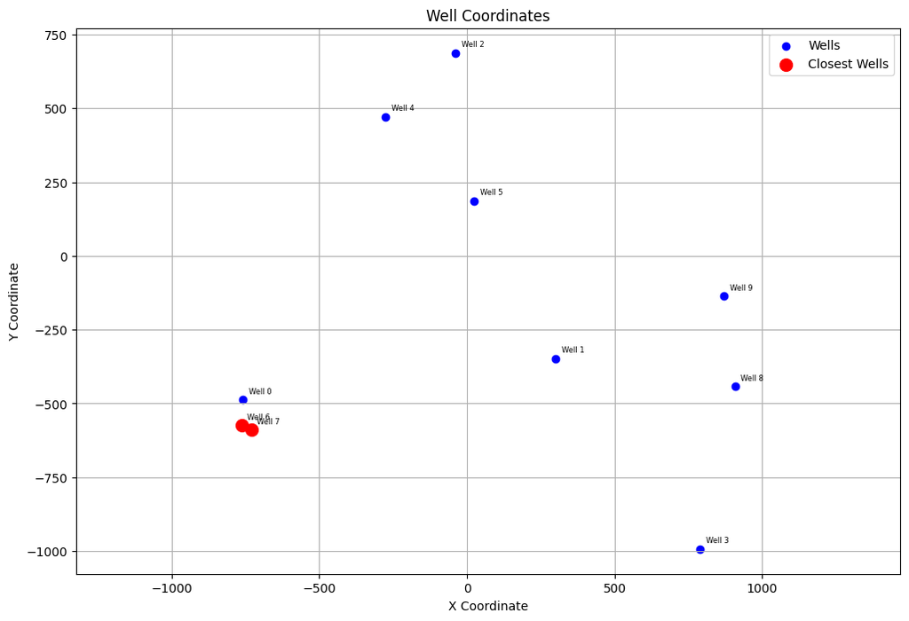

```python
import matplotlib.pyplot as plt

plt.figure(figsize=(12, 8))
x_coords = [coord[0] for coord in well_coords]
y_coords = [coord[1] for coord in well_coords]
plt.scatter(x_coords, y_coords, color='blue', label='Wells')

for i, (x, y) in enumerate(zip(x_coords, y_coords)):
    plt.annotate(f'Well {i}', (x, y), xytext=(5, 5), textcoords='offset points', fontsize=6)

min_well1, min_well2 = min_indices
plt.scatter([well_coords[min_well1][0], well_coords[min_well2][0]],
            [well_coords[min_well1][1], well_coords[min_well2][1]],
            color='red', s=100, label='Closest Wells')

plt.plot([well_coords[min_well1][0], well_coords[min_well2][0]],
         [well_coords[min_well1][1], well_coords[min_well2][1]],
         'r--', linewidth=1)

plt.title('Well Coordinates')
plt.xlabel('X Coordinate')
plt.ylabel('Y Coordinate')
plt.grid(True)
plt.legend()
plt.axis('equal')
plt.show()
```

### Task 2: Well Distance Classification

In this task, you will create a function to classify the distances of wells from an arbitrary point based on predefined distance ranges.

Part 1: Define the Classification Function

1. Define a function `classify_well_distances(well_coords, point)` that takes two arguments:
   - `well_coords`: A list of (x, y) tuples representing the coordinates of wells.
   - `point`: A tuple (x, y) representing the arbitrary point from which distances will be calculated.
2. Inside the function, create an empty list called `well_classifications`.
3. Iterate through the `well_coords` list.
4. For each well coordinate (x, y), calculate the distance from the `point` using the Pythagorean theorem.
5. Based on the calculated distance, append a string classification to the `well_classifications` list using the following criteria:
   - If the distance is less than or equal to 500 meters, append "Nearby"
   - If the distance is greater than 500 meters but less than or equal to 1000 meters, append "Moderate"
   - If the distance is greater than 1000 meters, append "Far"
6. Return the `well_classifications` list from the function.

Part 2: Test the Function

1. Use the `generate_well_coordinates(student_id)` function with your student ID to generate a list of 10 well coordinates.
2. Define an arbitrary point, for example, `point = (100, 200)`.
3. Call the `classify_well_distances` function with the generated well coordinates and the arbitrary point, and store the result in a variable.
4. Print the resulting list of well classifications.

This task challenges students to define a function that performs distance calculations and applies conditional statements to classify the distances into predefined categories. It also reinforces the concepts of iterating through lists, using the Pythagorean theorem, and working with tuples and lists.

By testing the function with their own well coordinates and an arbitrary point, students can verify the correctness of their implementation and gain practical experience in applying these concepts to petroleum engineering scenarios.

##### Part 1: define the main function to classify the wells

```python
def classify_well_distances(well_coords, point):
    """
    This function is written to Classify well distances based on selected point
    """
    well_classifications = []

    for x, y in well_coords:
        distance = math.sqrt((x - point[0]) ** 2 + (y - point[1]) ** 2)

        if distance <= 500:
            well_classifications.append("Nearby")
        elif distance <= 1000:
            well_classifications.append("Moderate")
        else:
            well_classifications.append("Far")

    return well_classifications
```

##### Part 2: Test the function

You can enter your target point like `x,y` or you can use test sample for default resulting

```python
# point = (100, 200)     # Test Sample

values = input("Please enter the point coordinates eg.,(100,200): \t").split(",")
x, y = map(float, values)
point = (x, y)
print(f"Your selected point coordinates are: {point}\n")

classification_results = classify_well_distances(well_coords, point)

for i, (coord, cls) in enumerate(zip(well_coords, classification_results)):
    print(f"Well {i}: Coordinate = {coord}, Classification = {cls}")
```

```
Your selected point coordinates are: (100.0, 200.0)

Well 0: Coordinate = (-760, -487), Classification = Far
Well 1: Coordinate = (299, -347), Classification = Moderate
Well 2: Coordinate = (-39, 688), Classification = Moderate
Well 3: Coordinate = (789, -993), Classification = Far
Well 4: Coordinate = (-276, 472), Classification = Nearby
Well 5: Coordinate = (25, 187), Classification = Nearby
Well 6: Coordinate = (-764, -575), Classification = Far
Well 7: Coordinate = (-731, -589), Classification = Far
Well 8: Coordinate = (908, -442), Classification = Far
Well 9: Coordinate = (871, -135), Classification = Moderate
```

#### Task 3: Reservoir Pressure Analysis

You are working for an oil and gas company that operates multiple reservoirs. Each reservoir is divided into grid blocks, and you have access to the pressure data for each grid block. Your task is to analyze the pressure data and provide insights into the reservoir performance.

The pressure data is stored in a NumPy array, where each row represents a grid block, and each column corresponds to a specific time step. The array has the following shape: `(num_grid_blocks, num_time_steps)`, where `num_grid_blocks` is the number of grid blocks in the reservoir, and `num_time_steps` is the number of time steps for which pressure data is available.

Your program should perform the following tasks:

1. Calculate the pressure gradient between adjacent grid blocks at each time step. The pressure gradient is the difference in pressure between two neighboring grid blocks. Store the pressure gradients in a new NumPy array with the same shape as the input pressure data array.
2. Identify the grid blocks with the highest and lowest pressure gradients at the last time step, and print their indices and corresponding pressure gradients.
3. Calculate the average pressure gradient across the entire reservoir at each time step, and store the results in a new NumPy array with shape `(num_time_steps,)`.
4. Plot the average pressure gradient over time using Matplotlib. Add a title, x-label, and y-label to the plot.
5. Implement a function `detect_anomalies(pressure_gradients, threshold)` that takes the pressure gradient array and a threshold value as input. The function should return a boolean mask indicating the grid blocks where the pressure gradient exceeds the threshold at any time step.
6. Apply the boolean mask from step 5 to the original pressure data array to extract the anomalous grid blocks, and print the indices of these grid blocks.

Use the provided function `generate_reservoir_data(student_id)` with your student ID as input to generate the pressure data array.

```python
import numpy as np

def generate_reservoir_data(student_id):
    """
    Generates pressure data for a reservoir with a fixed number of grid blocks and time steps.

    Args:
        student_id (int): A 9-digit integer representing the student's ID.

    Returns:
        numpy.ndarray: A 2D NumPy array representing the pressure data for the reservoir.
                       The array has shape (num_grid_blocks, num_time_steps).
    """
    # Set the random seed based on the student ID
    np.random.seed(student_id)

    # Define the number of grid blocks and time steps
    num_grid_blocks = 50
    num_time_steps = 100

    # Generate random pressure data for the reservoir
    pressure_data = np.random.randint(100, 500, size=(num_grid_blocks, num_time_steps))

    return pressure_data
```

I want to divide this section into two parts: functions and execution, so our division is as follows:

##### 1. functions

```python
def compute_pressure_gradients(pressure_data):
    """
    Calculate the pressure gradient between adjacent blocks

    Input:
        pressure_data of the form (num_grid_blocks, num_time_steps)

    Output:
        pressure_gradients of the same form
    """
    gradients = np.zeros_like(pressure_data)
    for i in range(1, pressure_data.shape[0]):
        gradients[i] = np.abs(pressure_data[i] - pressure_data[i - 1])
    return gradients

def find_extreme_gradients(pressure_gradients):
    """
    Finds the maximum and minimum pressure gradients in the last time step
    """
    last_step = pressure_gradients[:, -1]
    max_idx = np.argmax(last_step)
    min_idx = np.argmin(last_step)
    print(f"Maximum gradient in block {max_idx} = {last_step[max_idx]}")
    print(f"Minimum gradient in block {min_idx} = {last_step[min_idx]}")


def compute_mean_gradients(pressure_gradients):
    """
    Average pressure gradient at each time step

    Output:
        1D array of the form (num_time_steps,)
    """
    return np.mean(pressure_gradients, axis=0)


def plot_mean_gradients(mean_gradients):
    """
    Plot mean pressure gradient over time
    """
    plt.figure(figsize=(10, 5))
    plt.plot(mean_gradients, label='Mean Pressure Gradient', color='blue')
    plt.title('Mean Pressure Gradient Over Time')
    plt.xlabel('Time Step')
    plt.ylabel('Mean Pressure Gradient')
    plt.grid(True)
    plt.legend()
    plt.tight_layout()
    plt.show()


def detect_anomalies(pressure_gradients, threshold):
    """
    Detect anomalies based on threshold.
    """
    return pressure_gradients > threshold


def extract_anomalous_blocks(mask, pressure_data):
    """
    Identifies and extracts pressure data for grid blocks that meet anomaly criteria
    """
    indices = np.argwhere(mask)
    print("Anomalous Blocks Detected:")
    if len(indices) == 0:
        print("No anomalies found.")
        return
    for block, time in indices:
        print(f"Time Step: {time},  Grid Block: {block},  Pressure: {pressure_data[block, time]}")
    print(f"Total anomalies: {len(indices)}")
```

##### 2. excecution

```
Maximum gradient in block 45 = 356
Minimum gradient in block 0 = 0
```

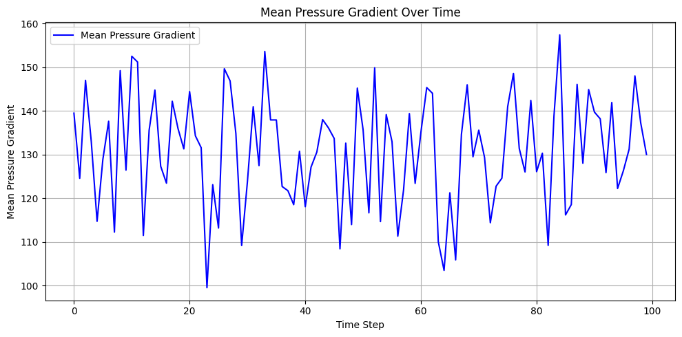

```
Anomalous Blocks Detected:
Time Step: 1,  Grid Block: 1,  Pressure: 409
Time Step: 6,  Grid Block: 1,  Pressure: 459
Time Step: 7,  Grid Block: 1,  Pressure: 128
Time Step: 8,  Grid Block: 1,  Pressure: 251
Time Step: 9,  Grid Block: 1,  Pressure: 418
Time Step: 13,  Grid Block: 1,  Pressure: 225
Time Step: 24,  Grid Block: 1,  Pressure: 102
Time Step: 27,  Grid Block: 1,  Pressure: 462
Time Step: 35,  Grid Block: 1,  Pressure: 250
Time Step: 36,  Grid Block: 1,  Pressure: 166
Time Step: 40,  Grid Block: 1,  Pressure: 222
Time Step: 43,  Grid Block: 1,  Pressure: 152
Time Step: 44,  Grid Block: 1,  Pressure: 187
Time Step: 45,  Grid Block: 1,  Pressure: 407
Time Step: 47,  Grid Block: 1,  Pressure: 106
Time Step: 48,  Grid Block: 1,  Pressure: 455
Time Step: 56,  Grid Block: 1,  Pressure: 364
Time Step: 59,  Grid Block: 1,  Pressure: 464
Time Step: 62,  Grid Block: 1,  Pressure: 219
Time Step: 69,  Grid Block: 1,  Pressure: 176
Time Step: 89,  Grid Block: 1,  Pressure: 217
Time Step: 93,  Grid Block: 1,  Pressure: 342
Time Step: 2,  Grid Block: 2,  Pressure: 173
Time Step: 6,  Grid Block: 2,  Pressure: 183
Time Step: 8,  Grid Block: 2,  Pressure: 483
Time Step: 10,  Grid Block: 2,  Pressure: 276
Time Step: 11,  Grid Block: 2,  Pressure: 489
Time Step: 14,  Grid Block: 2,  Pressure: 100
Time Step: 37,  Grid Block: 2,  Pressure: 193
Time Step: 45,  Grid Block: 2,  Pressure: 174
Time Step: 47,  Grid Block: 2,  Pressure: 330
Time Step: 48,  Grid Block: 2,  Pressure: 204
Time Step: 51,  Grid Block: 2,  Pressure: 338
Time Step: 64,  Grid Block: 2,  Pressure: 193
Time Step: 65,  Grid Block: 2,  Pressure: 116
Time Step: 67,  Grid Block: 2,  Pressure: 154
Time Step: 68,  Grid Block: 2,  Pressure: 453
Time Step: 74,  Grid Block: 2,  Pressure: 400
Time Step: 75,  Grid Block: 2,  Pressure: 487
```

[output cut: 1161 more lines]

```
Time Step: 39,  Grid Block: 49,  Pressure: 423
Time Step: 43,  Grid Block: 49,  Pressure: 359
Time Step: 49,  Grid Block: 49,  Pressure: 428
Time Step: 51,  Grid Block: 49,  Pressure: 155
Time Step: 59,  Grid Block: 49,  Pressure: 426
Time Step: 67,  Grid Block: 49,  Pressure: 359
Time Step: 70,  Grid Block: 49,  Pressure: 476
Time Step: 71,  Grid Block: 49,  Pressure: 483
Time Step: 79,  Grid Block: 49,  Pressure: 117
Time Step: 81,  Grid Block: 49,  Pressure: 485
Time Step: 84,  Grid Block: 49,  Pressure: 480
Time Step: 86,  Grid Block: 49,  Pressure: 130
Time Step: 98,  Grid Block: 49,  Pressure: 234
Time Step: 99,  Grid Block: 49,  Pressure: 423
Total anomalies: 1214
```

```python
pressure_data = generate_reservoir_data(student_id)

pressure_gradients = compute_pressure_gradients(pressure_data)

find_extreme_gradients(pressure_gradients)

mean_gradients = compute_mean_gradients(pressure_gradients)
plot_mean_gradients(mean_gradients)

threshold = 200
anomaly_mask = detect_anomalies(pressure_gradients, threshold)

extract_anomalous_blocks(anomaly_mask, pressure_data)
```

### Task 4: Reservoir Grid Block Analysis

**Description**: In petroleum reservoir management, reservoirs are divided into grid blocks to model fluid flow and pressure distribution. You are tasked with analyzing pressure and porosity data across a 3D reservoir grid to identify critical regions for drilling. This task focuses on multi-dimensional array manipulation, nested loops, and statistical computations using NumPy.

**Parts**:

1. **Data Generation**:
   - Use the provided function `generate_reservoir_grid(student_id)` to generate two 3D NumPy arrays:
     - `pressure_grid`: Shape `(10, 10, 5)` representing pressure (in psi) across a 10x10x5 grid (x, y, z dimensions).
     - `porosity_grid`: Shape `(10, 10, 5)` representing porosity (in percentage) across the same grid.
   - Compute and print the mean, standard deviation, minimum, and maximum pressure and porosity across the entire grid.
   - Compute and print the mean, standard deviation, minimum, and maximum pressure and porosity across each layer (z dimension).
2. **High-Pressure Zones**:
   - Identify grid blocks where the pressure exceeds 400 psi. Create a boolean array of the same shape as `pressure_grid` with `True` for blocks meeting this condition and `False` otherwise.
   - Count the number of high-pressure blocks and print their coordinates (i, j, k) and corresponding pressure values.
3. **Porosity-Pressure Correlation**:
   - For each z-layer (k=0 to 4), compute the element-wise product of pressure and porosity values in that layer (shape: `(10, 10)`). Store these products in a new 3D array of shape `(10, 10, 5)`.
   - Calculate the average product per layer and print these values. Identify the layer with the highest average product and print its index.
4. **Visualization**:
   - For the z=0 layer, create a heatmap using Matplotlib to visualize the pressure values. Use a colorbar and label the axes as "X Coordinate" and "Y Coordinate". Add a title "Pressure Distribution at z=0".

**Provided Code**:

```
import numpy as np

def generate_reservoir_grid(student_id):
    """
    Generates 3D pressure and porosity grids for a reservoir.

    Args:
        student_id (int): Student ID for random seed.

    Returns:
        tuple: (pressure_grid, porosity_grid) where each is a (10, 10, 5) array.
    """
    np.random.seed(student_id)
    pressure_grid = np.random.uniform(200, 500, size=(10, 10, 5))
    porosity_grid = np.random.uniform(5, 25, size=(10, 10, 5))
    return pressure_grid, porosity_grid
```

In this task we divide the codes based on the steps given in the question to solve this problem `(Data Generation, High Pressure Zones, Porosity Pressure Correlation, Visualization)` and we also consider a step called `Excecution` at the end of each steps to excecute the codes

##### 1. Data Generation

```python
def generate_reservoir_grid(student_id):
    """
    Generate 3D pressure and porosity grids for a reservoir.
    """
    np.random.seed(student_id)
    pressure_grid = np.random.uniform(200, 500, size=(10, 10, 5))
    porosity_grid = np.random.uniform(5, 25, size=(10, 10, 5))
    return pressure_grid, porosity_grid


def compute_global_statistics(pressure_grid, porosity_grid):
    """
    Compute and print global statistics (mean, std, min, max) for pressure and porosity.
    """
    print("Global Pressure Statistics:")
    print(f"Mean: {np.mean(pressure_grid):.2f}, Std: {np.std(pressure_grid):.2f}, "
          f"Min: {np.min(pressure_grid):.2f}, Max: {np.max(pressure_grid):.2f}")

    print("\nGlobal Porosity Statistics:")
    print(f"Mean: {np.mean(porosity_grid):.2f}, Std: {np.std(porosity_grid):.2f}, "
          f"Min: {np.min(porosity_grid):.2f}, Max: {np.max(porosity_grid):.2f}")


def compute_layer_statistics(pressure_grid, porosity_grid):
    """
    Compute and print statistics per layer (along z-axis) for pressure and porosity.
    """
    for k in range(pressure_grid.shape[2]):
        layer_pressure = pressure_grid[:, :, k]
        layer_porosity = porosity_grid[:, :, k]

        print(f"\nLayer z={k} Pressure Statistics:")
        print(f"Mean: {np.mean(layer_pressure):.2f}, Std: {np.std(layer_pressure):.2f}, "
              f"Min: {np.min(layer_pressure):.2f}, Max: {np.max(layer_pressure):.2f}")

        print(f"Layer z={k} Porosity Statistics:")
        print(f"Mean: {np.mean(layer_porosity):.2f}, Std: {np.std(layer_porosity):.2f}, "
              f"Min: {np.min(layer_porosity):.2f}, Max: {np.max(layer_porosity):.2f}")


pressure_grid, porosity_grid = generate_reservoir_grid(student_id)
compute_global_statistics(pressure_grid, porosity_grid)
compute_layer_statistics(pressure_grid, porosity_grid)
```

```
Global Pressure Statistics:
Mean: 351.46, Std: 85.55, Min: 200.24, Max: 498.39

Global Porosity Statistics:
Mean: 15.03, Std: 5.56, Min: 5.02, Max: 24.94

Layer z=0 Pressure Statistics:
Mean: 362.57, Std: 87.47, Min: 200.55, Max: 498.39
Layer z=0 Porosity Statistics:
Mean: 15.67, Std: 5.48, Min: 5.27, Max: 24.87

Layer z=1 Pressure Statistics:
Mean: 351.19, Std: 91.99, Min: 200.64, Max: 496.26
Layer z=1 Porosity Statistics:
Mean: 14.61, Std: 5.28, Min: 5.34, Max: 24.87

Layer z=2 Pressure Statistics:
Mean: 341.79, Std: 78.84, Min: 201.50, Max: 484.17
Layer z=2 Porosity Statistics:
Mean: 14.33, Std: 5.69, Min: 5.23, Max: 24.88

Layer z=3 Pressure Statistics:
Mean: 346.34, Std: 81.56, Min: 200.43, Max: 494.72
Layer z=3 Porosity Statistics:
Mean: 15.34, Std: 5.38, Min: 5.55, Max: 24.94

Layer z=4 Pressure Statistics:
Mean: 355.43, Std: 85.75, Min: 200.24, Max: 497.06
Layer z=4 Porosity Statistics:
Mean: 15.21, Std: 5.86, Min: 5.02, Max: 24.85
```

##### 2. High Pressure Zones

```python
def identify_high_pressure_blocks(pressure_grid, threshold=400):
    """
    Identify grid blocks with pressure above a specified threshold. (True, False)
    """
    return pressure_grid > threshold


def print_high_pressure_blocks(mask, pressure_grid):
    """
    Print the coordinates and pressure of all blocks where the mask is True.
    """
    indices = np.argwhere(mask)
    print(f"\nNumber of high pressure blocks (>400 psi): {len(indices)}")
    for idx in indices:
        i, j, k = idx
        print(f"Block (x={i}, y={j}, z={k}) - Pressure: {pressure_grid[i, j, k]:.2f} psi")


high_pressure_mask = identify_high_pressure_blocks(pressure_grid, threshold=400)
# print(f"Boolean high-pressure mask:\n{high_pressure_mask}")    # If you want to see the T/F grid blocks
print_high_pressure_blocks(high_pressure_mask, pressure_grid)
```

```
Number of high pressure blocks (>400 psi): 162
Block (x=0, y=0, z=2) - Pressure: 442.81 psi
Block (x=0, y=0, z=4) - Pressure: 482.13 psi
Block (x=0, y=1, z=1) - Pressure: 462.83 psi
Block (x=0, y=1, z=4) - Pressure: 407.15 psi
Block (x=0, y=2, z=1) - Pressure: 461.68 psi
Block (x=0, y=2, z=4) - Pressure: 443.94 psi
Block (x=0, y=3, z=0) - Pressure: 461.83 psi
Block (x=0, y=4, z=1) - Pressure: 460.66 psi
Block (x=0, y=5, z=0) - Pressure: 403.82 psi
Block (x=0, y=5, z=1) - Pressure: 426.07 psi
Block (x=0, y=6, z=0) - Pressure: 470.20 psi
Block (x=0, y=6, z=2) - Pressure: 453.82 psi
Block (x=0, y=7, z=4) - Pressure: 472.00 psi
Block (x=0, y=8, z=0) - Pressure: 473.67 psi
Block (x=0, y=8, z=4) - Pressure: 405.76 psi
Block (x=0, y=9, z=3) - Pressure: 440.75 psi
Block (x=1, y=0, z=0) - Pressure: 400.61 psi
Block (x=1, y=0, z=1) - Pressure: 462.98 psi
Block (x=1, y=0, z=4) - Pressure: 435.24 psi
Block (x=1, y=1, z=0) - Pressure: 484.74 psi
Block (x=1, y=2, z=1) - Pressure: 415.45 psi
Block (x=1, y=3, z=1) - Pressure: 436.72 psi
Block (x=1, y=3, z=2) - Pressure: 432.79 psi
Block (x=1, y=3, z=4) - Pressure: 475.75 psi
Block (x=1, y=4, z=0) - Pressure: 447.70 psi
Block (x=1, y=5, z=2) - Pressure: 432.91 psi
Block (x=1, y=6, z=1) - Pressure: 486.75 psi
Block (x=1, y=7, z=0) - Pressure: 478.66 psi
Block (x=1, y=7, z=1) - Pressure: 435.86 psi
Block (x=1, y=7, z=3) - Pressure: 443.65 psi
Block (x=1, y=8, z=0) - Pressure: 439.74 psi
Block (x=1, y=8, z=1) - Pressure: 412.58 psi
Block (x=1, y=8, z=2) - Pressure: 459.54 psi
Block (x=1, y=8, z=3) - Pressure: 464.17 psi
Block (x=1, y=8, z=4) - Pressure: 486.74 psi
Block (x=2, y=0, z=0) - Pressure: 404.65 psi
Block (x=2, y=0, z=2) - Pressure: 433.28 psi
Block (x=2, y=0, z=4) - Pressure: 465.24 psi
Block (x=2, y=2, z=0) - Pressure: 498.39 psi
```

[output cut: 108 more lines]

```
Block (x=8, y=8, z=2) - Pressure: 484.17 psi
Block (x=8, y=8, z=4) - Pressure: 452.07 psi
Block (x=8, y=9, z=0) - Pressure: 432.67 psi
Block (x=9, y=0, z=4) - Pressure: 442.11 psi
Block (x=9, y=2, z=2) - Pressure: 409.69 psi
Block (x=9, y=3, z=1) - Pressure: 452.90 psi
Block (x=9, y=4, z=3) - Pressure: 487.06 psi
Block (x=9, y=4, z=4) - Pressure: 464.86 psi
Block (x=9, y=6, z=1) - Pressure: 432.08 psi
Block (x=9, y=7, z=0) - Pressure: 449.99 psi
Block (x=9, y=7, z=1) - Pressure: 444.09 psi
Block (x=9, y=7, z=2) - Pressure: 452.37 psi
Block (x=9, y=7, z=3) - Pressure: 417.82 psi
Block (x=9, y=8, z=4) - Pressure: 474.90 psi
Block (x=9, y=9, z=3) - Pressure: 409.90 psi
```

##### 3. Porosity Pressure Correlation

```python
def compute_pressure_porosity_product(pressure_grid, porosity_grid):
    """
    Compute element-wise product of pressure and porosity for each layer.
    Returns a 3D array of the same shape.
    """
    return pressure_grid * porosity_grid


def compute_layerwise_product_means(product_grid):
    """
    Compute mean of the pressure-porosity product for each z-layer.
    Identify the layer with the highest mean and print the result.
    """
    means = []
    print("Mean Products for each layer:")
    for k in range(product_grid.shape[2]):
        layer_mean = np.mean(product_grid[:, :, k])
        means.append(layer_mean)
        print(f"Layer z={k} Mean Product: {layer_mean:.2f}")

    max_layer_index = np.argmax(means)
    print(f"\nLayer with highest mean product: z={max_layer_index}")
    return max_layer_index


product_grid = compute_pressure_porosity_product(pressure_grid, porosity_grid)
# print(product_grid)   # If you want to see the product grid in (5,10,10) array
compute_layerwise_product_means(product_grid)
```

```
Mean Products for each layer:
Layer z=0 Mean Product: 5605.37
Layer z=1 Mean Product: 5192.31
Layer z=2 Mean Product: 4903.04
Layer z=3 Mean Product: 5336.68
Layer z=4 Mean Product: 5422.91

Layer with highest mean product: z=0
```

```
np.int64(0)
```

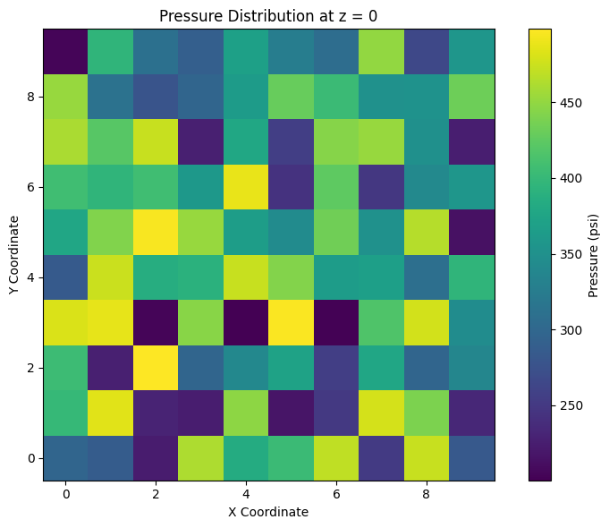

```python
def plot_pressure_heatmap_layer0(pressure_grid):
    """
    Plot a heatmap of pressure values for layer z=0.
    """
    plt.figure(figsize=(8, 6))
    plt.imshow(pressure_grid[:, :, 0], cmap='viridis', origin='lower')
    plt.colorbar(label='Pressure (psi)')
    plt.title('Pressure Distribution at z = 0')
    plt.xlabel('X Coordinate')
    plt.ylabel('Y Coordinate')
    plt.tight_layout()
    plt.show()


plot_pressure_heatmap_layer0(pressure_grid)
```

#### Task 5: Working with CSV data

For this task you should import well-logging data from a CSV file using pandas and identify the pay zone. You are required to identify the pay zone by applying a set of cutoffs and calculate the height of the pay zone. Finally, you should present your findings in a clear and concise manner.

Along with the Homework notebook, there is a CSV data file (`wellDATA.csv`). The file contains well-logging data, which includes four columns: `DEPTH`, `PHIE`, `SWE`, and `VSH`. These columns represent the depth of the well, porosity, effective water saturation, and volume of shale respectively.

First you should import this dataset using PANDAS library and getting in touch with it by examining it.

```
import pandas as pd

df = pd.read_csv('wellDATA.csv') # This will load the data into pandas dataframe object
df.head() # This will print some first rows of data for examination
```

Then you should identify each depth as payzones or non-payzones by applying the following cutoffs:

- PHIE >= 7%
- SWE <= 30%
- VSH <= 30%

The result should be stored in a new column of your dataframe (`df`) assigning `1s` for payzones and `0s` for non-payzones.

Next you should calculate the height of the payzones through the result of the last step and report it.

**Hints:**

- **Do not forget Google to learn concepts you do not know**
- You can convert each colomn of pandas dataframe into numpy array by the following code:

  ```
  PHIE = df['PHIE'].to_numpy()
  ```

- You can add new columns to your dataframe like this:

  ```
  #Assume "payzone_flag" is the numpy array containing the payzones and non-payzones you have identified.
      df['payzone_flag'] = payzone_flag
  ```

Based on the question description, I divided the code into 3 parts (`Data importing, Payzone Detection, Height of Payzones`), and below is the code for each part.

#### 1. Data Imorting using pandas

```python
import pandas as pd

df = pd.read_csv('wellDATA.csv')

df.head()
```

|  | DEPTH | PHIE | SWE | VSH |
| --- | --- | --- | --- | --- |
| 0 | 2280.0 | 0.098936 | 0.6589 | 0.165324 |
| 1 | 2280.1 | 0.120352 | 0.6506 | 0.194339 |
| 2 | 2280.2 | 0.138746 | 0.6113 | 0.194433 |
| 3 | 2280.3 | 0.146975 | 0.6588 | 0.206715 |
| 4 | 2280.4 | 0.184781 | 0.6172 | 0.208941 |

```python
df.info()
```

```
<class 'pandas.core.frame.DataFrame'>
RangeIndex: 10595 entries, 0 to 10594
Data columns (total 4 columns):
 #   Column  Non-Null Count  Dtype
---  ------  --------------  -----
 0   DEPTH   10595 non-null  float64
 1   PHIE    10595 non-null  float64
 2   SWE     10595 non-null  float64
 3   VSH     10595 non-null  float64
dtypes: float64(4)
memory usage: 331.2 KB
```

So we figure out there is no null data to be removed.

```python
df.describe()
```

|  | DEPTH | PHIE | SWE | VSH |
| --- | --- | --- | --- | --- |
| count | 10595.000000 | 10595.000000 | 10595.000000 | 10595.000000 |
| mean | 2809.700000 | 0.105948 | 0.623233 | 0.148966 |
| std | 305.865739 | 0.058218 | 0.241857 | 0.200357 |
| min | 2280.000000 | 0.000001 | 0.000000 | 0.000001 |
| 25% | 2544.850000 | 0.058818 | 0.444700 | 0.016119 |
| 50% | 2809.700000 | 0.107614 | 0.600600 | 0.071066 |
| 75% | 3074.550000 | 0.148849 | 0.814800 | 0.160153 |
| max | 3339.400000 | 0.287315 | 1.000000 | 0.931162 |

##### 2. Payzone Detection

In this section based on the details that given in task description:

- PHIE >= 7%
- SWE <= 30%
- VSH <= 30%

```python
payzone_flag = (
    (df['PHIE'] >= 0.07) &
    (df['SWE'] <= 0.3) &
    (df['VSH'] <= 0.3)
).astype(int)

df['payzone_flag'] = payzone_flag
df.head()
```

|  | DEPTH | PHIE | SWE | VSH | payzone_flag |
| --- | --- | --- | --- | --- | --- |
| 0 | 2280.0 | 0.098936 | 0.6589 | 0.165324 | 0 |
| 1 | 2280.1 | 0.120352 | 0.6506 | 0.194339 | 0 |
| 2 | 2280.2 | 0.138746 | 0.6113 | 0.194433 | 0 |
| 3 | 2280.3 | 0.146975 | 0.6588 | 0.206715 | 0 |
| 4 | 2280.4 | 0.184781 | 0.6172 | 0.208941 | 0 |

##### 3. Heigh of Payzone

first of all lets find where payzone_flag is True

```python
df[df['payzone_flag'] == 1]
```

|  | DEPTH | PHIE | SWE | VSH | payzone_flag |
| --- | --- | --- | --- | --- | --- |
| 100 | 2290.0 | 0.082421 | 0.0823 | 0.021599 | 1 |
| 101 | 2290.1 | 0.110048 | 0.0644 | 0.037524 | 1 |
| 102 | 2290.2 | 0.125811 | 0.0787 | 0.058288 | 1 |
| 103 | 2290.3 | 0.134241 | 0.1935 | 0.068510 | 1 |
| 104 | 2290.4 | 0.152689 | 0.1898 | 0.094164 | 1 |
| ... | ... | ... | ... | ... | ... |
| 10229 | 3302.9 | 0.151302 | 0.2543 | 0.187655 | 1 |
| 10230 | 3303.0 | 0.155365 | 0.2530 | 0.153489 | 1 |
| 10231 | 3303.1 | 0.154676 | 0.2592 | 0.134069 | 1 |
| 10232 | 3303.2 | 0.156438 | 0.2732 | 0.138253 | 1 |
| 10233 | 3303.3 | 0.157458 | 0.2907 | 0.154426 | 1 |

562 rows × 5 columns

```python
payzone_depths = df[df['payzone_flag'] == 1]['DEPTH'].to_numpy()

payzone_height = sum(np.diff(payzone_depths))

print(f"Estimated payzone heigh: {payzone_height:.2f} ft")
```

```
Estimated payzone heigh: 1013.30 ft
```

#### Task 6: Plotting

1. Import the `wellDATA.csv` using `PANDAS` library. Plot **scatters** of PHIE vs. DEPTH, SWE vs. DEPTH, VSH vs. DEPTH and, payzone_flag vs. DEPTH using `matplotlib`. Note: All of the plots should be placed in `one figure` and each log should be displayed in `a column` (so you figure should have `4` columns).
2. Plot 3D scatter plot of (SWE, VSH, DEPTH) color the points with payzone_flag value and size the points with the value of PHIE

Your plots should be titled and their axis should be labeled appropriately.

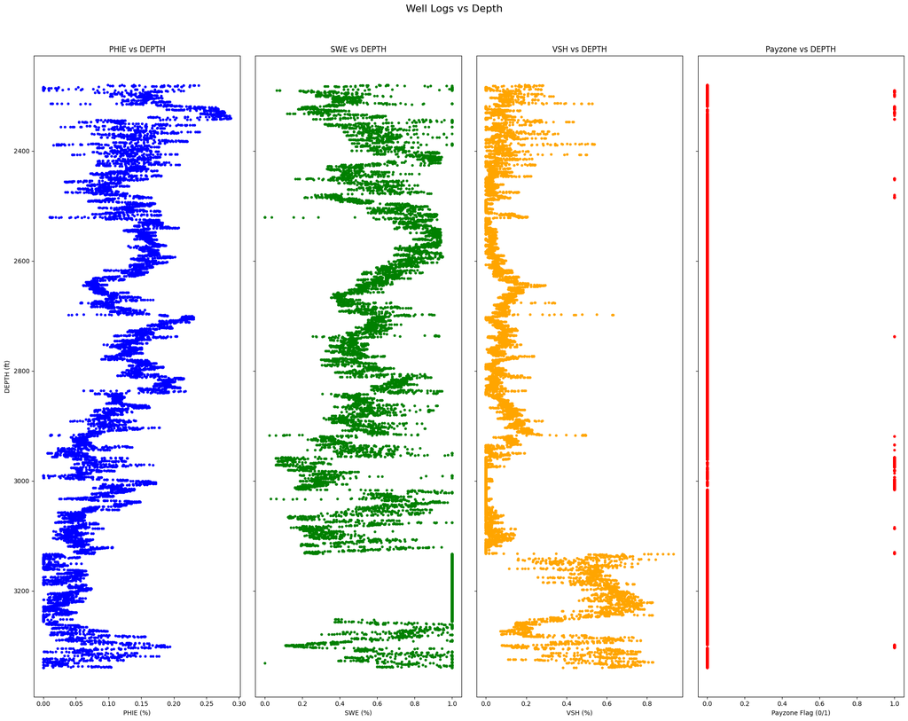

```python
"""
Notice that before using this section, you should run the last section codes for importing csv file with pandas
"""

fig, axs = plt.subplots(1, 4, figsize=(20, 15), sharey=True)

axs[0].scatter(df['PHIE'], df['DEPTH'], color='blue', s=10)
axs[0].set_xlabel('PHIE (%)')
axs[0].set_ylabel('DEPTH (ft)')
axs[0].invert_yaxis()
axs[0].set_title('PHIE vs DEPTH')

axs[1].scatter(df['SWE'], df['DEPTH'], color='green', s=10)
axs[1].set_xlabel('SWE (%)')
axs[1].set_title('SWE vs DEPTH')

axs[2].scatter(df['VSH'], df['DEPTH'], color='orange', s=10)
axs[2].set_xlabel('VSH (%)')
axs[2].set_title('VSH vs DEPTH')

axs[3].scatter(df['payzone_flag'], df['DEPTH'], color='red', s=10)
axs[3].set_xlabel('Payzone Flag (0/1)')
axs[3].set_title('Payzone vs DEPTH')

plt.tight_layout()
plt.suptitle('Well Logs vs Depth', fontsize=16, y=1.05)

plt.show()
```

#### Task 7: Debugging

Each of the following code cells has one or more erros `Find them`, `fix them` and `write the reason` causes the error.

```python
import numpy as np

def matrix_operations(A, B, C, D, E):
    # Step 1: Matrix multiplication of A and B
    result1 = A @ B

    # Step 2: Elementwise multiplication of result1 and C
    result2 = result1 * C[:, :result1.shape[1]]

    # Step 3: Matrix multiplication of result2 and D
    result3 = result2 @ D

    # Step 4: Elementwise multiplication of result3 and E
    result4 = result3 * E[:, 0]

    # Step 5: Calculate the sum of result4
    final_result = np.sum(result4, axis=1)

    return final_result

# Test case
A = np.random.randint(1, 10, size=(5, 3))
B = np.random.randint(1, 10, size=(3, 4))
C = np.random.randint(1, 10, size=(5, 5))
D = np.random.randint(1, 10, size=(4, 2))
E = np.random.randint(1, 10, size=(2, 3))

result = matrix_operations(A, B, C, D, E)
print("Final result:", result)

# Your tasks:

# 1. Identify and fix the bugs in the provided code to ensure that the matrix operations are performed correctly.
# 2. Explain the issues that caused the bugs.
# 3. Provide the correct output for the given test case after fixing the bugs.
```

```
Final result: [87718 53872 39920 38751 34012]
```

Bug1: in result3 = result2 @ D[:-1]: The slicing D[:-1] gives a shape of (3, 2), which is incompatible with result2 shape (5, 4) — matrix multiplication requires `result2.shape[1] == D.shape[0]`.

- Fix: Use full D without slicing.

Bug2: in result4 = result3 * E.T: result3 has shape (5,2) and E.T has shape (3,2), which cannot be broadcast for elementwise multiplication.

- Fix: Use one column of E (e.g., E[:, 0]) to get a (2,) array that can be broadcast to (5,2).

```python
''' The following program is supposed to take a list of numbers as input and return a new list
    that contains only the odd numbers in the original list.
    However, there is a bug in the program that causes it to return an empty list. Can you
    identify and fix the bug?'''

def filter_odd_numbers(numbers):
    odd_numbers = []     # This list should define before loop
    for num in numbers:
        if num % 2 != 0:
            odd_numbers.append(num)
        else:
            pass
    return odd_numbers

# Test the function
numbers = [1, 2, 3, 4, 5, 6, 7, 8, 9, 10]
result = filter_odd_numbers(numbers)
print(result)
```

```
[1, 3, 5, 7, 9]
```

There was only 1 bug as follows:

- odd_number list should define before loop to change in each loop

```python
'''
The following code should perform these tasks:
    1- Calculates the sum of all the elements in the array.
    2- Calculates the product of all the even elements in the array.
    3- Replaces all odd elements in the array with -1.

But there are some bugs in it
'''

import numpy as np

# Create a numpy array
arr = np.array([1, 2, 3, 4, 5, 6, 7, 8, 9, 10])

# Initialize sum and product variables
total_sum = 0
even_product = 1

# Iterate over the array using a for loop
for ind in range(len(arr)):   # Or range(0,len(arr))
    element = arr[ind]

    total_sum += element

    if element % 2 == 0:
        even_product *= element

    else:
        arr[ind] = -1

    # arr[ind] = -1    This line should be deleted


# Print the results
print("Sum of all elements:", total_sum)
print("Product of all even elements:", even_product)
print("Array after replacing odd elements with -1:")
print(arr)
```

```
Sum of all elements: 55
Product of all even elements: 3840
Array after replacing odd elements with -1:
[-1  2 -1  4 -1  6 -1  8 -1 10]
```

Bug1 :Loop starts from index 1 instead of 0 — this skips the first element.

- Fix: Use range(len(arr)).

Bug2 :even_product initialized to 0 — multiplying by 0 always results in 0.

- Fix: Initialize it to 1.

Bug3 :All values were being replaced with -1, not just odd ones — because arr `[ind] = -1` was outside the if block.

- Fix: Move the replacement line inside the if `element % 2 != 0`: block.

Bug4 :Unused variable selected = (arr == element) — had no effect.

- Fix: Removed it.

```python
"""
This code should calculate the density of each oil sample and print each of them in a line.
Its result should be:
    The density of the oil sample is: 1000.0000000000001 g/cm^3
    The density of the oil sample is: 894.1176470588235 g/cm^3
    The density of the oil sample is: 1100.0 g/cm^3
"""


oil_samples = [[820, 0.82], [760, 0.85], [880, 0.80]] # This array contains the mass and volume of 3 oil samples. For example for the first sample the mass is 820 and the volume is 0.82

def calculate_density(mass, volume):
    # density = mass / volume
    # return density
    return mass/volume

for sample in oil_samples:
    mass, volume = sample
    density = calculate_density(mass, volume)
    print("The density of the oil sample is:", density, "g/cm^3")
```

```
The density of the oil sample is: 1000.0000000000001 g/cm^3
The density of the oil sample is: 894.1176470588235 g/cm^3
The density of the oil sample is: 1100.0 g/cm^3
```

Bug1 :Function calculate_density didn't return anything

- Fix: Added `return mass / volume` or `return density`.

Bug2 :Inside the loop, it always used oil_samples[0] instead of iterating

- Fix: Replaced with `mass, volume = sample` to access each item.

Bug3 :The print statement was outside the loop, so only one result printed

- Fix: Moved it inside the loop.

```python
# The function minimum() should find the minimum of a given list but it doesn't seem to work fine. Why?


def minimum(input_list):
    a = float("inf")
    for x in range(0, len(input_list)):
        if input_list[x] < a:
            a = input_list[x]
    return a

a = [3, 4, 2, 6, 1, 7, 7, 8]

print(minimum(a))
```

```
1
```

There was only 1 bug as follows:

- 0 is smaller than every positive number, so the function should return 0 when the input is 0. When we want to find the minimum of a list of numbers, we should start from larger number eg., `1000000000 , infinity (float("inf))`

```python
'''
The following code tries to remove all elements of the list wich starts with the letter t,
but the 'three' have remained in the printed results why? '''

nums = ['zero', 'one', 'two', 'three', 'four']

for num in nums[:]:
    if num.startswith('t'):
        nums.remove(num)

print(nums)
```

```
['zero', 'one', 'four']
```

This problem happens due to modifying a list while iterating over it. There are 3 ways to solve this problem:

- 1 -> we can append our new values in a new list instead of removing it (its most common way to solve it). eg., `nums = [num for num in nums if not num.startswith('t')]`
- 2 -> we can iterate on a copy of our list, in this way we are not modifying the original list. eg., `for num in nums[:]:` and we are find sth on our new list (without operation on it) and remove it on our original list . eg., `nums.remove(num)`
- 3 -> we can use filter approach eg., `list(filter(lambda x: not x.startswith('t'), nums))`, it is better version for removing elements from list while iterating over it instead of typical loops.

```python
import numpy as np

def calculate_reservoir_volume(thickness, area, porosity):
    """
    Calculates the total pore volume of a reservoir grid.
    Args:
        thickness: 2D array of shape (n, m) with grid block thicknesses (ft).
        area: 2D array of shape (n, m) with grid block areas (sq ft).
        porosity: 2D array of shape (n, m) with porosity percentages.
    Returns:
        Total pore volume (cu ft).
    """
    volume = 0
    for i in range(thickness.shape[0]):
        for j in range(thickness.shape[1]):
            volume += thickness[i, j] * area[i, j] * porosity[i, j]
    return volume

# Test case
thickness = np.ones((5, 5)) * 10
area = np.ones((5, 5)) * 1000
porosity = np.full((5, 5), 0.04)
volume = calculate_reservoir_volume(thickness, area, porosity)
print("Total pore volume:", volume, "cu ft")



'''
- Fix the code to compute the total pore volume correctly (Pore volume is calculated as `thickness * area * porosity`
 per grid block, summed over all blocks).
- Explain each error and its impact.
- Provide the corrected output for the test case (should be 10000 cu ft).
'''
```

```
Total pore volume: 10000.0 cu ft
```

```
'\n- Fix the code to compute the total pore volume correctly (Pore volume is calculated as `thickness * area * porosity`\n per grid block, summed over all blocks).\n- Explain each error and its impact.\n- Provide the corrected output for the test case (should be 10000 cu ft).\n'
```

There was only 1 bug as the following:

- Used `porosity[i]` which gives a full row instead of a scalar, causing unexpected behavior. We should change it to `porosity[i, j]` for correct scalar access.
- Also if we change the value of porosity to 0.04, the amswer will be 10000 cu ft

```python
import numpy as np

def smooth_production_rates(rates):
    """
    Applies a 3-day moving average to smooth production rates.
    Args:
        rates: 1D array of daily production rates.
    Returns:
        Smoothed rates array.
    """
    smoothed = np.zeros_like(rates, dtype=float)
    for i in range(len(rates)):
        start = max(0, i - 1)
        end = min(len(rates), i + 2)
        smoothed[i] = np.mean(rates[start:end])
    return smoothed

# Test case
rates = np.array([100, 120, 110, 130, 125, 90, 140, 130, 110, 80])
smoothed = smooth_production_rates(rates)
print("Smoothed rates:", smoothed[1:-2])



'''
- Fix the code to compute a 3-day moving average correctly.
- Explain each error and its impact.
- Provide the corrected output for the test case.
'''
```

```
Smoothed rates: [110.         120.         121.66666667 115.         118.33333333
 120.         126.66666667]
```

```
'\n- Fix the code to compute a 3-day moving average correctly.\n- Explain each error and its impact.\n- Provide the corrected output for the test case.\n'
```

There was only 1 bug as the following:

After completing all the tasks, please, `convert it to PDF`, zip it with your answers notebook (`ipynb file`) and send it.

MAKE SURE TO HAVE THE RESULTS OF THE CODES IN YOUR FILES

Have notes and explanations along with your results

Novin Nekuee (403134029)

Regards